# explain the desciption to the data

## Primary Health Center Shortfalls

```
##    Min. 1st Qu.  Median    Mean 3rd Qu.    Max.
## -1010.0    -9.5     5.0   152.0   144.0  1480.0
```

The states to be worried about are **West Bengal**, **Uttar Pradesh**, **Bihar**. The state of Karnataka is seeing amazing progress in PHCs as there is a huge surplus of PHCs and Govt. is putting in the maximum effort as compared to all the other states and uts. According to this dataset based on the rural population in different states, Tamil Nadu is not doing so bad but this [article in Hindu](http://www.thehindu.com/todays-paper/tp-features/tp-downtown/article2309749.ece?css=print) does not ??depict?? that.

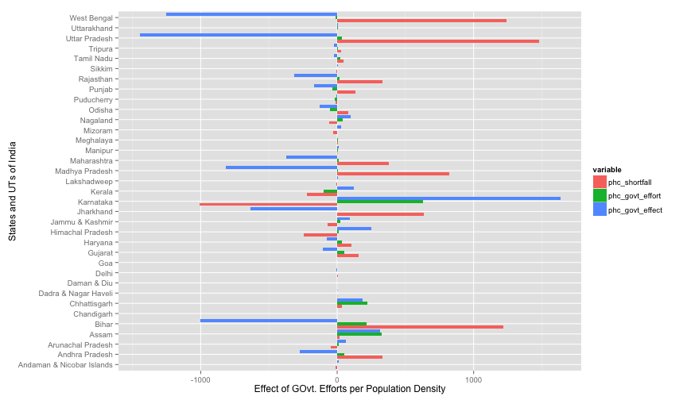

## Community Health Center Shortfalls

```
##    Min. 1st Qu.  Median    Mean 3rd Qu.    Max.
##   -78.0    -2.0     3.0    71.0    69.5   778.0
```

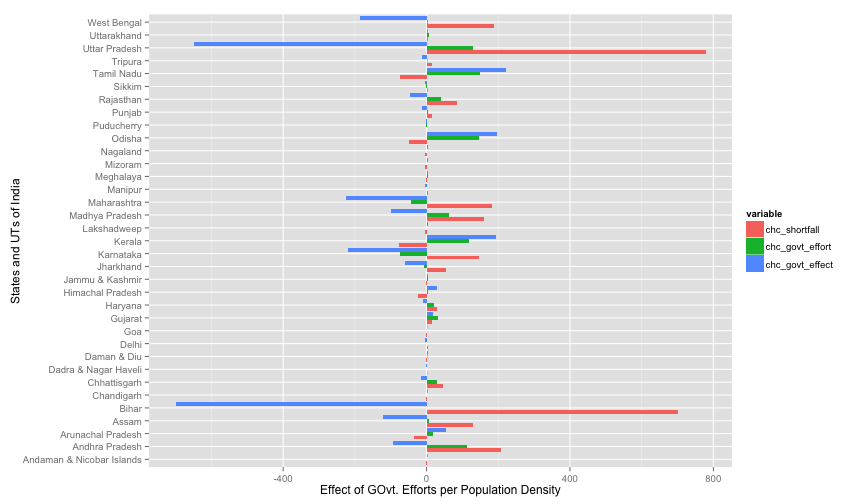